# CodingSample

This sample is broken up into two sections, which reflect the two means through which I learned to code Python.

The first section reflects self-study via Harvard's online CS50 lectures for Python and their corresponding exercises. The second sections reflects some of my data visualization work at CSU Northridge.

A link with the instructions for each CS50 exercise is included just above my solutions. As far as I'm aware, there are no solutions to these exercises posted online by Harvard. The solutions provided below are uniquely my own and can be cross-checked with community solutions posted online to validate their uniqueness.

## Section 1: CS50

```python
#//////////////////////////////////////////////////////////////////////////////
# https://cs50.harvard.edu/python/2022/psets/2/plates/
# Vanity Plates
```

```python
def main():
    plate = input("Plate: ")
    if is_valid(plate):
        print("Valid")
    else:
        print("Invalid")

#---------------------------------------------------------------

def is_valid(s):
    if 2 <= len(s) <= 6 and s[0].isalpha() and s[1].isalpha():

        # Flag variable
        has_numeric = False

        # Digits cannot appear in the middle of a license plate
        for i in range(2, len(s)):
            if s[i].isdigit():
                has_numeric = True
            elif s[i].isalpha() and has_numeric:
                return False

            # The first digit cannot be zero
            if i >= 2 and s[i] == '0' and s[i-1].isalpha():
                return False
            else:
              pass

            # No periods, spaces, punctuation marks, or special characters
            if s[i] in ['.', ' ', ',', ';', ':', '?', '!', '-', '_', '+', '=', '@', '#', '$', '%', '^', '&', '*', '(', ')']:
                return False

        return True

    else:
        return False

#---------------------------------------------------------------

main()
```

```python
#//////////////////////////////////////////////////////////////////////////////
# https://cs50.harvard.edu/python/2022/psets/2/camel/
# camelCase
```

```python
camelCase = input('Enter camelCase variable name: ')

snake_case = ''

for char in camelCase:

  if char.isupper():
    char = char.lower()
    snake_case += '_'
    snake_case += str(char)

  else:
    snake_case += str(char)

print(snake_case)
```

```python
#//////////////////////////////////////////////////////////////////////////////
# https://cs50.harvard.edu/python/2022/psets/2/coke/
# Coke Machine
```

```python
left_owed = 50
print('One can of Coca-Cola is $0.50')

#---------------------------------
while True:

  if left_owed > 0:
    coin_value = int(input('Insert coin: '))

    if coin_value == 25 or coin_value == 10 or coin_value == 5:
      left_owed = left_owed - coin_value
      print(f'{left_owed} cents left')
    else:
      print('Invalid coin. Only 25, 10, and 5 cent coins are accepted.')
      continue

  else:
      break
#---------------------------------

if left_owed < 0:
  print(f' Change is {left_owed - (2*left_owed)} cents. Enjoy your Coke!')
else:
  print('Enjoy your Coke!')
```

```python
#//////////////////////////////////////////////////////////////////////////////
# https://cs50.harvard.edu/python/2022/psets/2/twttr/
# Just setting up my twttr
```

```python
vowel_string = input('Give a string: ')
no_vowels = ''

for char in vowel_string:
  match str(char):
    case 'A'|'E'|'I'|'O'|'U'|'a'|'e'|'i'|'o'|'u':
      no_vowels += ''
    case _:
      no_vowels += str(char)

print(no_vowels)
```

```python
#//////////////////////////////////////////////////////////////////////////////
# https://cs50.harvard.edu/python/2022/psets/3/fuel/
# Fuel Gauge
```

```python
def main():

  X, Y = input_filter()

  if X/Y >= 0.99:
    print('F')
  elif X/Y <= 0.01:
    print('E')
  else:
    print(str(round(X/Y*100)) + '%')

#---------------------------------------------------------------

def input_filter():
  while True:

    try:
      fraction_input = input('Enter fuel gauge in the form X/Y: ')
      X, Y = map(int, fraction_input.split('/'))
      return X, Y

    except (ValueError, ZeroDivisionError):
      print('Please follow the formatting guidelines.')

    else:
      return X, Y

#---------------------------------------------------------------

main()
```

```python
#%%%%%%%%%%%%%%%%%%%%%%%%%%%%%%%%%%%%%%%%%%%%%%%%%%%%%%%%%%%%%%%%%%%%%%%%%%%%%%
#%%%%%%%%%%%%%%%%%%%%%%%%%%%%%%%%%%%%%%%%%%%%%%%%%%%%%%%%%%%%%%%%%%%%%%%%%%%%%%
#%%%%%%%%%%%%%%%%%%%%%%%%%%%%%%%%%%%%%%%%%%%%%%%%%%%%%%%%%%%%%%%%%%%%%%%%%%%%%%
```

## Section 2: Data Visualization

```python
import matplotlib.pyplot as plt
from matplotlib_venn import venn2

import seaborn as sns
import pandas as pd
import numpy as np

from sklearn import linear_model
from sklearn.metrics import mean_squared_error, r2_score
from sklearn.model_selection import train_test_split
```

```python
df = pd.read_csv('student.csv')
df.head(3)
```

|  | gender | ethnicity | parental_education | lunch | test_preparation_course | math_score | reading_score | writing_score |
| --- | --- | --- | --- | --- | --- | --- | --- | --- |
| 0 | female | group B | bachelor's degree | standard | none | 72 | 72 | 74 |
| 1 | female | group C | some college | standard | completed | 69 | 90 | 88 |
| 2 | female | group B | master's degree | standard | none | 90 | 95 | 93 |

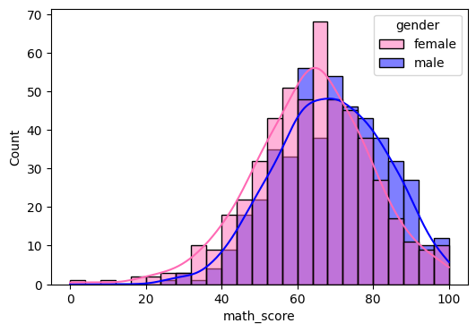

```python
# How to visualize math_score distribution across gender
plt.figure(figsize=(6,4))
sns.histplot(data=df, x='math_score', hue='gender',
             palette={'female':'hotpink', 'male':'blue'},
             kde=True)
plt.show()
```

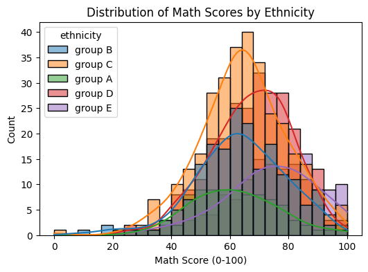

```python
plt.figure(figsize=(6,4))
sns.histplot(data=df, x='math_score', hue='ethnicity',
             kde=True)

plt.title('Distribution of Math Scores by Ethnicity')
plt.xlabel('Math Score (0-100)')
plt.ylabel('Count')

plt.show()
```

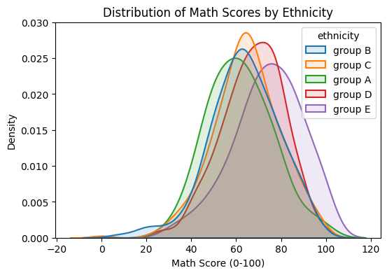

```python
plt.figure(figsize=(6,4))
sns.kdeplot(data=df, x='math_score', hue='ethnicity',
            fill=True, common_norm=False,
            alpha=0.15,
            linewidth=1.5)

plt.title('Distribution of Math Scores by Ethnicity')
plt.xlabel('Math Score (0-100)')
plt.ylabel('Density')

plt.show()
```

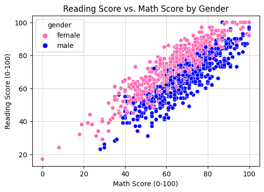

```python
plt.figure(figsize=(6,4))
sns.scatterplot(df, x='math_score', y='reading_score',
                hue='gender', palette={'male':'blue','female':'hotpink'})
plt.grid(True, alpha=0.5)

plt.title('Reading Score vs. Math Score by Gender')
plt.xlabel('Math Score (0-100)')
plt.ylabel('Reading Score (0-100)')

plt.show()
```

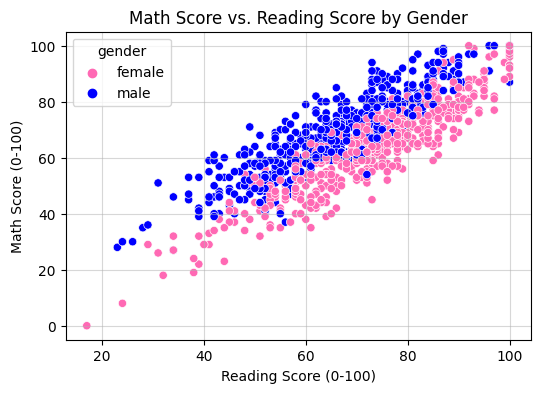

```python
plt.figure(figsize=(6,4))
sns.scatterplot(df, x='reading_score', y='math_score',
                hue='gender', palette={'male':'blue','female':'hotpink'})
plt.grid(True, alpha=0.5)

plt.title('Math Score vs. Reading Score by Gender')
plt.xlabel('Reading Score (0-100)')
plt.ylabel('Math Score (0-100)')

plt.show()
```

```python
df = pd.read_csv('annual_gold.csv')
df.tail(3)
```

|  | Date | Gold | Platinum |
| --- | --- | --- | --- |
| 31 | 2017-12 | 1265.674 | 950.49 |
| 32 | 2018-12 | 1249.887 | 882.18 |
| 33 | 2019-12 | 1480.025 | 868.04 |

```python
# We change the data type of Date from object to datetime
df['Date'] = pd.to_datetime(df['Date'])
df.head(1)
```

|  | Date | Gold | Platinum |
| --- | --- | --- | --- |
| 0 | 1986-12-01 | 391.595 | 465.29 |

```python
df['Year'] = df['Date'].dt.year
df.head(1)
```

|  | Date | Gold | Platinum | Year |
| --- | --- | --- | --- | --- |
| 0 | 1986-12-01 | 391.595 | 465.29 | 1986 |

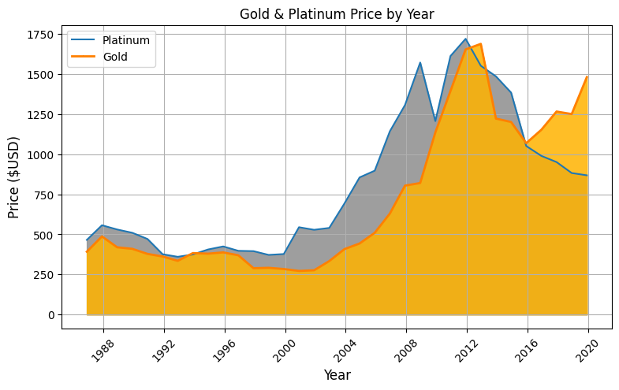

```python
plt.figure(figsize=(9,5))

#-------------------------------------------------------------------------------

# Platinum
sns.lineplot(data=df, x='Date', y='Platinum', label='Platinum')
plt.fill_between(x=df['Date'], y1=df['Platinum'], color='#999999', alpha=0.95)

#-------------------------------------------------------------------------------

# Gold
plt.plot_date(x=df['Date'], y=df['Gold'], linestyle='-',
             color='#ff8000', linewidth=2, marker=',',
              label='Gold')
plt.fill_between(x=df['Date'], y1=df['Gold'], color='#ffb300', alpha=0.85)

#-------------------------------------------------------------------------------

plt.xticks(rotation=45)
plt.xlabel('Year', size=12)
plt.ylabel('Price ($USD)', size=12)
plt.title('Gold & Platinum Price by Year')

plt.legend(loc = 'upper left')
plt.grid(True)
plt.show()
```

```python
#%%%%%%%%%%%%%%%%%%%%%%%%%%%%%%%%%%%%%%%%%%%%%%%%%%%%%%%%%%%%%%%%%%%%%%%%%%%%%%
```

Building a Regression Model

```python
df = pd.read_csv('salary.csv')
df.head(3)
```

|  | YearsExperience | Salary |
| --- | --- | --- |
| 0 | 1.2 | 39344 |
| 1 | 1.4 | 46206 |
| 2 | 1.6 | 37732 |

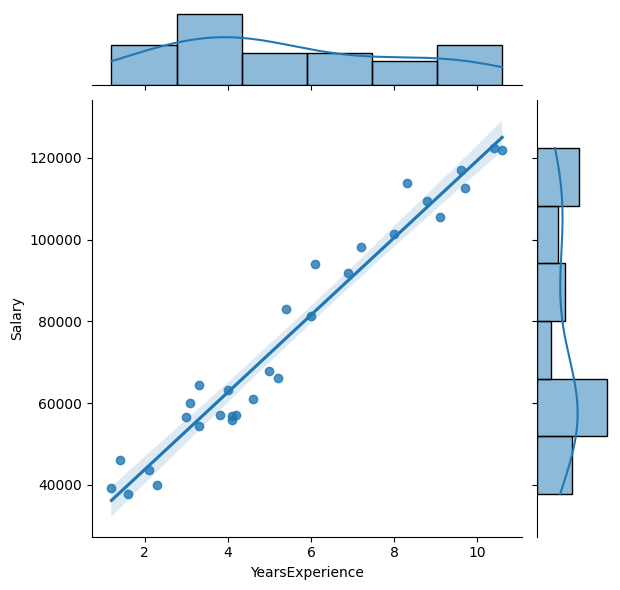

```python
# Creating a jointplot to explore the relationship between experience and salary

plt.figure(figsize=(6,6))
sns.jointplot(data=df, x='YearsExperience', y='Salary', kind='reg')
plt.show()
```

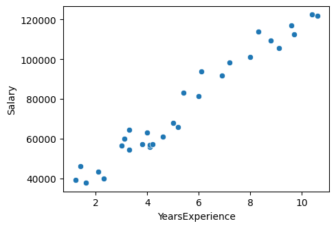

```python
# Displaying the relationship between x and y using scatterplot
plt.figure(figsize=(5,3.5))
sns.scatterplot(data=df, x='YearsExperience', y='Salary')
plt.show()
```

```python
# Model building

# Double brackets creates a pandas dataframe
x = df[['YearsExperience']]
y = df[['Salary']]
```

```python
# Split the data
x_train, x_test, y_train, y_test = train_test_split(x, y, test_size=0.1)
```

```python
regr = linear_model.LinearRegression()
regr.fit(x_train, y_train)
```

```
LinearRegression()
```

```python
# Model prediction
y_pred = regr.predict(x_test)
y_pred
```

```
array([[ 99711.56993733],
       [ 37375.87620897],
       [102545.01056134]])
```

```python
np.sqrt(mean_squared_error(y_test, y_pred))
```

```
8316.075232121839
```

```python
r2_score(y_test, y_pred)
```

```
0.9198218331733488
```

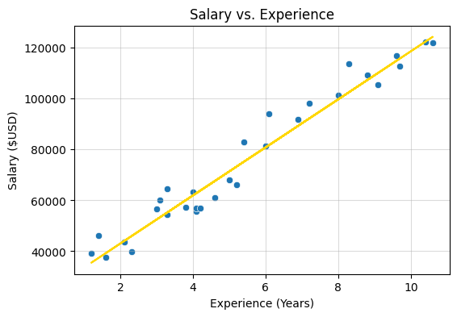

```python
# Visualing the model

plt.figure(figsize=(6,4))

sns.scatterplot(data=df, x='YearsExperience', y='Salary')
plt.plot(x_train, regr.predict(x_train), color='gold')

plt.title('Salary vs. Experience')
plt.xlabel('Experience (Years)')
plt.ylabel('Salary ($USD)')

plt.grid(True, alpha=0.45)
plt.show()
```

```python
print('slope:', regr.coef_)
print('intercept:', regr.intercept_)
```

```
slope: [[9444.80208005]]
intercept: [24153.1532969]
```

```python
# Model:
#   y = 24153 + 9445x
```

```python
#%%%%%%%%%%%%%%%%%%%%%%%%%%%%%%%%%%%%%%%%%%%%%%%%%%%%%%%%%%%%%%%%%%%%%%%%%%%%%%
```

The following selection of visualizations appear in a final consumer analysis project for a data visualization class I completed at CSU Northridge. For the sake of brevity, I did not transfer over the lengthy analysis portion, nor all the visualizations, although the project in its entirety can be provided if needed.

```python
df = pd.read_csv('Customers.csv')
df.head(3)
```

|  | CustomerID | Gender | Age | Annual Income ($) | Spending Score (1-100) | Profession | Work Experience | Family Size |
| --- | --- | --- | --- | --- | --- | --- | --- | --- |
| 0 | 1 | Male | 19 | 15000 | 39 | Healthcare | 1 | 4 |
| 1 | 2 | Male | 21 | 35000 | 81 | Engineer | 3 | 3 |
| 2 | 3 | Female | 20 | 86000 | 6 | Engineer | 1 | 1 |

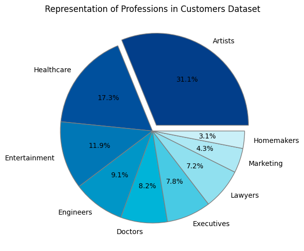

```python
profession = df['Profession'].value_counts().tolist()
plabels = ['Artists', 'Healthcare', 'Entertainment', 'Engineers', 'Doctors', 'Executives', 'Lawyers', 'Marketing', 'Homemakers']
colors = ['#023e8a', '#00509d', '#0077b6', '#0096c7', '#00b4d8', '#48cae4', '#90e0ef', '#ade8f4', '#caf0f8']
explode = (0.075, 0, 0, 0, 0, 0, 0, 0, 0)

plt.figure(figsize=(6,6))

plt.pie(profession, labels=plabels, colors=colors, autopct='%1.1f%%', explode=explode, wedgeprops={'linewidth':1,
'edgecolor':'grey'})

plt.title('Representation of Professions in Customers Dataset')
plt.show()
```

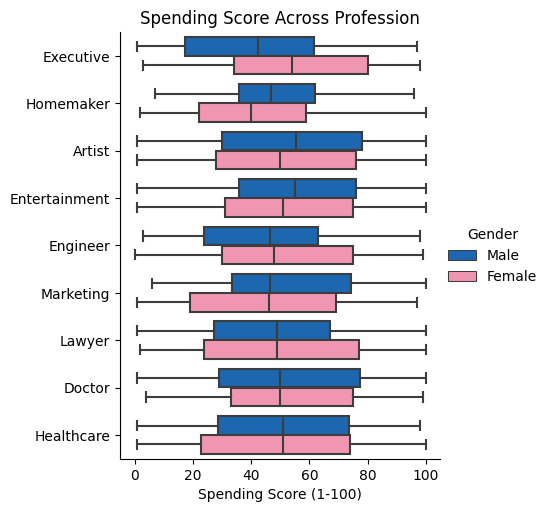

```python
plt.figure(figsize=(6,4))
profession_order = ['Executive', 'Homemaker', 'Artist', 'Entertainment', 'Engineer', 'Marketing', 'Lawyer', 'Doctor', 'Healthcare']

sns.catplot(data=df, x='Spending Score (1-100)', y='Profession', kind='box', hue='Gender',
            palette={'Female':'#ff87ab', 'Male':'#0466c8'}, orient='h', order=profession_order)

plt.ylabel('')
plt.title('Spending Score Across Profession')
plt.show()
```

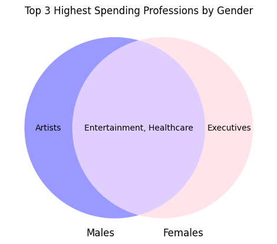

```python
a = set(['Artists', 'Healthcare', 'Entertainment'])
b = set(['Executives', 'Healthcare', 'Entertainment'])

ven = venn2(subsets=(a,b), set_labels=('Males', 'Females'),
      set_colors=('blue', 'pink'))

ven.get_label_by_id('10').set_text(', '.join(a-b))
ven.get_label_by_id('11').set_text(', '.join(a&b))
ven.get_label_by_id('01').set_text(', '.join(b-a))

plt.title('Top 3 Highest Spending Professions by Gender')
plt.show()
```

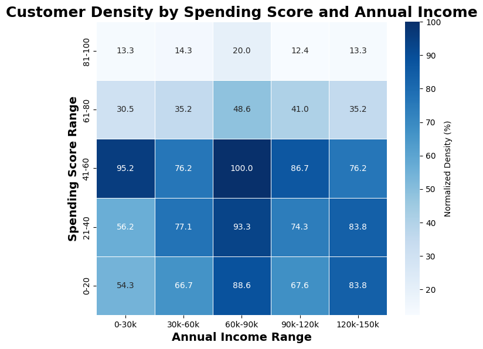

```python
# Define the specific bins for income and spending score
income_bins = [0, 30000, 60000, 90000, 120000, 150000]
spending_bins = [0, 20, 40, 60, 80, 100]

# Create the 2D histogram with swapped axes
hist_swapped, spending_edges, income_edges = np.histogram2d( df['Annual Income ($)'], df['Spending Score (1-100)'], bins=[income_bins, spending_bins])

# Normalize the swapped histogram
normalized_hist_swapped = (hist_swapped / hist_swapped.max()) * 100

# Create the figure and axis for the heatmap with swapped axes
plt.figure(figsize=(1,1))
fig, ax = plt.subplots(figsize=(8,6.5))

# Create the heatmap with swapped axes
sns.heatmap(normalized_hist_swapped,
            xticklabels=['0-30k', '30k-60k', '60k-90k', '90k-120k', '120k-150k'],
            yticklabels=['81-100', '61-80', '41-60', '21-40', '0-20'],
            cmap='Blues',
            ax=ax,
            annot=True,
            fmt=".1f",
            linewidths=.5,
            cbar_kws={'label': 'Normalized Density (%)'})

# Add titles and labels with axes swapped
plt.title('Customer Density by Spending Score and Annual Income', fontsize=18, fontweight='bold')
plt.xlabel('Annual Income Range', fontsize=14, fontweight='bold')
plt.ylabel('Spending Score Range', fontsize=14, fontweight='bold')
plt.show()
```